# Doing Data Science

### What is Data Science?

Data Science is an interdisciplinary field that involves the use of scientific methods, processes, algorithms, and systems to extract knowledge and insights from structured and unstructured data. It involves combining knowledge and techniques from statistics, mathematics, computer science, and domain-specific knowledge to analyze and understand complex phenomena and solve problems.

Data Science encompasses a wide range of activities, including data collection, cleaning, integration, analysis, modeling, and visualization, as well as the communication of findings and insights to stakeholders. It involves the use of various tools, techniques, and technologies, including statistical software, machine learning algorithms, data visualization tools, and big data platforms.

Data Science has numerous applications across industries, including finance, healthcare, marketing, social media, and many others. The insights and predictions derived from data analysis can be used to drive business decisions, inform policy, and improve the lives of individuals and communities.

### How to do Data Science?

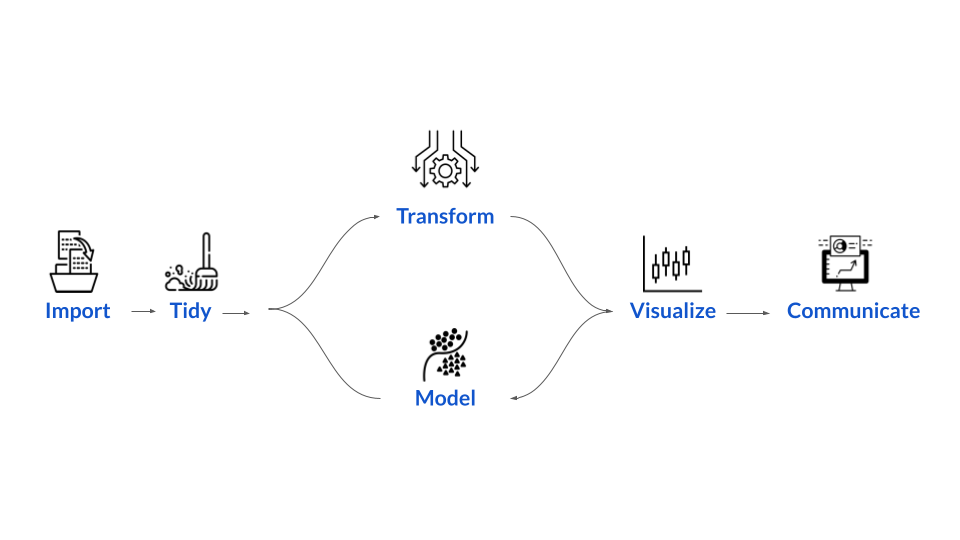

The first step almost always is to **import** data. Data comes in different forms and shapes: files, databases, APIs etc. Before you can start analyzing data, you need to bring it into the environment you are working with.

The real fun starts after you have transformed your data. The next step in the journey is to **visualize** it. Visualizations let you explore the data and gain insights.

An equally important part of the workflow is to **model** the data. This involves analyzing hypotheses on the data as well as building predictions.

The **transform** > **visualize** > **model** cycle is usually a highly iterative one and one will find themselves tweaking each step repeatedly till you find the optimal solution.

The last step in the workflow is to **communicate** the data. This is done by turning your analysis into reports, dashboards, web apps and other artifacts that can be shared across a broad range of stakeholders.

Our focus in this course will largely be on the **transform** and **visualize** steps.

### Why R & Tidyverse?

One of the biggest strengths of R is its extensive ecosystem of **packages**. An R package is a suite of functions along with data and documentation, that extends the functionality of base R.

The Tidyverse is a highly opinionated set of packages that share a common underlying grammar and philosophy and are designed to work together to execute the data science workflow.

Rather than talk about the beauty of the `tidyverse`, I want you to experience it for yourself by working through the next lesson that uses the tidyverse to turn a dataset of US baby names into a beautiful animated bar chart.